# SR 13 and 14

## **13M2. Compare the models you fit just above, using WAIC. Can you reconcile the differences in WAIC with the posterior distributions of the models?**

```r
#compare(m13.1a, m13.1b, m13.1c)
```

## **13M3. Re-estimate the basic Reed frog varying intercept model, but now using a Cauchy distribution in place of the Gaussian distribution for the varying intercepts. That is, fit this model:**

$$s_i \sim Binomial(n_i, p_i)\\
logit(p_i) = \alpha_{TANK[i]}\\
\alpha_{TANK} \sim Cauchy(\alpha,\sigma)\\
\alpha \sim Normal(0, 1)\\
\sigma \sim Exponential(1)\\$$

Let’s put this into code:

```r
# with gaussian prior
#set.seed(013122)
#m13.1g  <- ulam(
#alist(
#S ~ dbinom(N,p),
#logit(p) <- a[tank],
#a[tank] ~ dnorm(a_bar, sigma),
#a_bar ~ dnorm(0, 1.5),
#sigma ~ dexp(1)), data = d, chains = 4, log_lik = TRUE)

# with cauchy prior

#m13.1 <- ulam( alist(
#S ~ dbinom(N, p),
#logit(p) <- a[tank],
#a[tank] ~ dcauchy(a_bar, sigma),
#a_bar ~ dnorm(0, 1),
#sigma ~ dexp(1)), data = d, chains = 4, log_lik = TRUE)

# question on divergent transitions
#divergent(m13.1)

# questions on comparing means
# coeftab(m13.1, m13.1g)
```

## **13M4. Now use a Student-t distribution with ν = 2 for the intercepts:**

$\alpha_{TANK} ∼ Student(2, \alpha,\sigma)$  
**Refer back to the Student-t example in Chapter 7 (page 234), if necessary. Compare the resulting posterior to both the original model and the Cauchy model in 13M3. Can you explain the differences and similarities in shrinkage in terms of the properties of these distributions?**

```r
#student t distribution in prior
library(rethinking)
library(dplyr)
set.seed(122022)
m13.1s <- ulam( alist(
S ~ dbinom(N, p),
logit(p) <- a[tank],
a[tank] ~ dstudent(2, a_bar, sigma),
a_bar ~ dnorm(0, 1.5),
sigma ~ dexp(1)), data = d, chains = 4, log_lik = TRUE)
```

[output not shown]

```
## Chain 1 Informational Message: The current Metropolis proposal is about to be rejected because of the following issue:
```

[output not shown]

```
## Chain 1 If this warning occurs sporadically, such as for highly constrained variable types like covariance matrices, then the sampler is fine,
```

```
## Chain 1 but if this warning occurs often then your model may be either severely ill-conditioned or misspecified.
```

```
## Chain 1
```

[output not shown]

```
## Chain 2 Informational Message: The current Metropolis proposal is about to be rejected because of the following issue:
```

[output not shown]

```
## Chain 2 If this warning occurs sporadically, such as for highly constrained variable types like covariance matrices, then the sampler is fine,
```

```
## Chain 2 but if this warning occurs often then your model may be either severely ill-conditioned or misspecified.
```

```
## Chain 2
```

[output not shown]

```r
# comparison
# coeftab(m13.1, m13.1g, m13.1s)
```

## **13M5. Modify the cross-classified chimpanzees model m13.4 so that the adaptive prior for blocks contains a parameter $\bar\gamma$ for its mean:**

$$\gamma \sim Normal(\bar\gamma,\sigma_{\gamma})\\
\bar\gamma \sim Normal(0, 1.5)$$

## **Compare this model to m13.4. What has including $\bar\gamma$ done?**

```r
# load data
data(chimpanzees)
data <- tibble(chimpanzees)

# transform data, and select only things needed for the model
dat_list  <- data %>%
  mutate(treatment = 1 + prosoc_left + 2 * condition) %>%
  mutate(block_id = block) %>%
  mutate(treatment = as.integer(treatment)) %>%
  select(pulled_left, actor, block_id, treatment)

# model without gamma-bar
set.seed(13)
m13.4a <- ulam(
alist(
pulled_left ~ dbinom(1,p),
logit(p) <- a[actor] + g[block_id] + b[treatment],
b[treatment] ~ dnorm(0, 0.5),
a[actor] ~ dnorm(a_bar, sigma_a),
g[block_id] ~ dnorm(0, sigma_g),
a_bar ~ dnorm(0,1.5),
sigma_a ~ dexp(1),
sigma_g ~ dexp(1)) , data = dat_list, chains = 4, cores = 4, log_lik = TRUE)
```

[output not shown]

```r
# model with gamma-bar
set.seed(13)
m13.4b <- ulam(alist(
pulled_left ~ dbinom(1, p),
logit(p) <- a[actor] + g[block_id] + b[treatment],
b[treatment] ~ dnorm(0, 0.5),
a[actor] ~ dnorm(a_bar, sigma_a),
g[block_id] ~ dnorm(g_bar, sigma_g),
a_bar ~ dnorm(0, 1.5),
g_bar ~ dnorm(0, 1.5),
sigma_a ~ dexp(1),
sigma_g ~ dexp(1)
) ,data = dat_list, chains = 4,cores = 4, log_lik = TRUE)
```

[output not shown]

```r
# compare

compare(m13.4a, m13.4b)
```

```
##            WAIC       SE      dWAIC       dSE    pWAIC    weight
## m13.4b 532.2215 19.50110 0.00000000        NA 10.74822 0.5056072
## m13.4a 532.2663 19.38305 0.04485929 0.3362275 10.73260 0.4943928
```

```r
precis(m13.4b, 2, pars = c("a", "b","g", "sigma_g", "g_bar"))
```

```
##                mean        sd        5.5%       94.5%    n_eff    Rhat4
## a[1]    -0.61831219 1.0998457 -2.30986755  1.16233330 295.6744 1.015423
## a[2]     4.50089403 1.6564106  2.19145185  7.13241985 385.9628 1.001777
## a[3]    -0.89864642 1.0863801 -2.55054730  0.84925596 304.5074 1.010254
## a[4]    -0.90389156 1.0908123 -2.59923475  0.83031658 303.9577 1.009048
## a[5]    -0.61495896 1.0891075 -2.29758370  1.10204370 294.1960 1.014244
## a[6]     0.34133938 1.0817869 -1.32954915  2.08732915 309.7138 1.010003
## a[7]     1.89015991 1.1325047  0.11150243  3.69562425 300.5842 1.011301
## b[1]    -0.16513288 0.2947609 -0.62818465  0.30081226 450.2918 1.016091
## b[2]     0.37669691 0.2862480 -0.09259323  0.81788627 604.2678 1.007327
## b[3]    -0.50474068 0.2971793 -0.98323091 -0.02870139 714.0454 1.006232
## b[4]     0.27003414 0.3031536 -0.21931987  0.71951073 438.4667 1.009633
## g[1]     0.09701816 1.0938681 -1.67547605  1.76960160 260.5273 1.017675
## g[2]     0.30513070 1.0842509 -1.47056620  1.98408835 286.4301 1.013107
## g[3]     0.32807302 1.0785607 -1.39993430  2.00736700 282.8833 1.013159
## g[4]     0.27896409 1.0901976 -1.48086345  1.97457565 277.1541 1.013600
## g[5]     0.23478598 1.0844777 -1.52211360  1.92489035 270.0517 1.015570
## g[6]     0.37926506 1.0856745 -1.39647085  2.04462120 295.7205 1.011573
## sigma_g  0.22380764 0.1765217  0.04707885  0.53442031 394.2236 1.014970
## g_bar    0.26787894 1.0717688 -1.46185745  1.92692750 277.2942 1.014108
```

```r
precis(m13.4a, 2, pars = c("a", "b", "g", "sigma_g"))
```

```
##                 mean        sd         5.5%       94.5%     n_eff     Rhat4
## a[1]    -0.367589261 0.3596180 -0.941542995  0.22455135  572.0095 1.0037565
## a[2]     4.620008805 1.2863160  3.026051850  6.78534185  720.4670 1.0023716
## a[3]    -0.671717827 0.3703038 -1.284155300 -0.07930272  626.9429 1.0044333
## a[4]    -0.665175230 0.3644561 -1.277798050 -0.10900505  623.3603 1.0030791
## a[5]    -0.360023078 0.3656518 -0.947495035  0.21199991  677.9544 1.0018323
## a[6]     0.576127607 0.3671682 -0.002665405  1.17527890  561.3093 1.0045842
## a[7]     2.106764151 0.4686412  1.389680200  2.87967260  700.1257 1.0040178
## b[1]    -0.131005514 0.3015011 -0.605322690  0.34940934  610.2244 1.0041123
## b[2]     0.405009429 0.3035400 -0.073329930  0.90068681  619.7941 1.0016464
## b[3]    -0.470428520 0.3049855 -0.958576045  0.00261029  589.8346 1.0032233
## b[4]     0.280501020 0.3011763 -0.188790225  0.75564694  607.2497 1.0041857
## g[1]    -0.185702192 0.2178343 -0.586706970  0.07108232  680.4218 1.0059754
## g[2]     0.037852920 0.1811201 -0.230221610  0.34788747 1277.4377 0.9989643
## g[3]     0.055786502 0.1819976 -0.200693390  0.36817323 1054.3381 1.0003744
## g[4]     0.004709123 0.1838587 -0.293344065  0.30117936 1353.6755 1.0007138
## g[5]    -0.028278152 0.1747931 -0.313453520  0.24118645 1221.0113 1.0003955
## g[6]     0.120776610 0.1979242 -0.137575530  0.47542285 1120.4761 1.0019107
## sigma_g  0.225482193 0.1748964  0.035561201  0.50142372  440.4279 1.0123727
```

## **13M6. Sometimes the prior and the data(through the likelihood) are in conflict, because they concentrate around different regions of parameter space. What happens in these cases depends a lot upon the shape of the tails of the distributions. Likewise, the tails of distributions strongly influence can outliers are shrunk or not towards the mean. I want you to consider four different models to fit to one observation at y = 0. The models differ only in the distributions assigned to the likelihood and prior. Here are the four models:**

Model NN:
$$y \sim Normal(\mu, 1)\\
\mu \sim Normal(10, 1)$$

```r
# Let's load the data and build the model
data(chimpanzees)
data2 <- tibble(chimpanzees) %>%
  select(pulled_left)

# Model NN
m_NN <- ulam(
  alist(
    pulled_left ~ dnorm(mu, 1),
    mu ~ dnorm(10, 1)),
  data = data2, chains = 2)
```

[output not shown]

Model TN:
$$y \sim Student(2, \mu, 1)\\
\mu \sim Normal(10, 1)$$

```r
# Model TN
m_TN <- ulam(
  alist(
    pulled_left ~ dstudent(2,mu, 1),
    mu ~ dnorm(10, 1)),
  data = data2, chains = 2)
```

[output not shown]

Model NT:
$$y \sim Normal(\mu, 1)\\
\mu \sim Student(2, 10, 1)$$

```r
# Model NT
m_NT <- ulam(
  alist(
    pulled_left ~ dnorm(mu, 1),
    mu ~ dstudent(2,10, 1)),
  data = data2, chains = 2)
```

[output not shown]

Model TT:
$$y \sim Student(2, \mu, 1)\\
\mu \sim Student(2, 10, 1)$$

```r
# Model TT
m_TT <- ulam(
  alist(
    pulled_left ~ dstudent(2,mu, 1),
    mu ~ dstudent(2,10, 1)),
  data = data2, chains = 2)
```

[output not shown]

## **Estimate the posterior distributions for these models and compare them. Can you explain the results, using the properties of the distributions?**

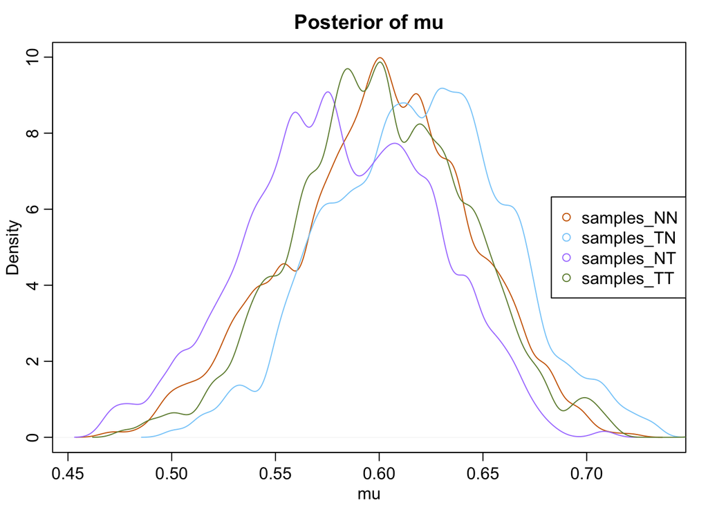

```r
# estimate for NN
library(tidybayes)
library(dplyr)


# Extract posterior samples
samples_NN <- extract.samples(m_NN)
samples_TN <- extract.samples(m_TN)
samples_NT <- extract.samples(m_NT)
samples_TT <- extract.samples(m_TT)


dens(samples_NN$mu, col="darkorange3", main = "Posterior of mu", xlab = "mu")
dens(samples_TN$mu, col="lightskyblue", add = TRUE)
dens(samples_NT$mu, col="mediumpurple1", add=TRUE)
dens(samples_TT$mu, col="darkolivegreen4", add=TRUE)
legend("right", legend = c("samples_NN", "samples_TN", "samples_NT", "samples_TT" ), col = c("darkorange3", "lightskyblue", "mediumpurple1", "darkolivegreen4" ), pch = 1)
```

# chapter 14

## **14E1. Add to the following model varying slopes on the predictor x.**

$$y_i \sim Normal(\mu_i, \sigma)\\
\mu_i = \alpha_{GROUP[i]} + \beta x_i\\
\alpha_{GROUP} \sim Normal(\bar\alpha, \sigma_{\alpha})\\
\bar\alpha \sim Normal(0, 10)\\
\beta \sim Normal(0, 1)\\
\sigma \sim Exponential(1)\\
\sigma_{\alpha} \sim Exponential(1)\\$$

## **14E2. Think up a context in which varying intercepts will be positively correlated with varying slopes. Provide a mechanistic explanation for the correlation.**

## **14E3. When is it possible for a varying slopes model to have fewer effective parameters (as estimated by WAIC or PSIS) than the corresponding model with fixed (unpooled) slopes? Explain.**

## **14M1. Repeat the café robot simulation from the beginning of the chapter. This time, set $\rho$ to zero, so that there is no correlation between intercepts and slopes. How does the posterior distribution of the correlation reflect this change in the underlying simulation?**

## **14M2. Fit this multilevel model to the simulated café data:**

$$W_i \sim Normal(\mu_i, \sigma)\\
\mu_i = \alpha_{CAFÉ[i]} + \beta_{CAFÉ[i]}Ai\\
\alpha_{CAFEÉ} \sim Normal(\alpha,\sigma_{\alpha})\\
\beta_{CAFÉ} \sim Normal(\beta,\sigma_{\beta})\\
\alpha \sim Normal(0, 10)\\
\beta \sim Normal(0, 10)\\
\sigma,\sigma_{\alpha}.\sigma_{\beta} \sim Exponential(1)$$

```r
# need to reorganize all of this code
set.seed(22)
N_visits <-10
N_cafes <- 20
a <- 3.5
b <- (-1)
sigma_a <- 1
sigma_b <- 0.5
rho <- (-0.7)
Mu <-c(a,b)

cov_ab <-sigma_a*sigma_b*rho
Sigma <-matrix(c(sigma_a^2,cov_ab,cov_ab,sigma_b^2),ncol=2)

library(MASS)
set.seed(5)
vary_effects <-mvrnorm(N_cafes,Mu,Sigma)

a_cafe  <-vary_effects[,1]
b_cafe <-vary_effects[,2]

# set up the data for tibble
afternoon <-rep(0:1, N_visits * N_cafes / 2)
cafe_id <-rep(1:N_cafes, each = N_visits)
mu <-a_cafe[cafe_id] + b_cafe[cafe_id] * afternoon
sigma <-0.5
wait <-rnorm(N_visits*N_cafes,mu,sigma)
data3 <- tibble(cafe=cafe_id,afternoon=afternoon,wait=wait)


# create model
set.seed(867530)
m14.1 <-ulam(
alist(
wait ~ normal(mu,sigma),
mu <- a_cafe[cafe] + b_cafe[cafe] * afternoon,
a_cafe[cafe] ~ normal(a_bar, sigma_a),
b_cafe[cafe] ~ normal(b_bar, sigma_b),
a_bar ~ normal(0,10),
b_bar ~ normal(0,10),
sigma_a ~ dexp(1),
sigma_b ~ dexp(1),
sigma ~ dexp(1)
) ,data = data3, chains = 4, cores = 4)
```

[output not shown]

```
## Chain 2 Informational Message: The current Metropolis proposal is about to be rejected because of the following issue:
```

[output not shown]

```
## Chain 2 If this warning occurs sporadically, such as for highly constrained variable types like covariance matrices, then the sampler is fine,
```

```
## Chain 2 but if this warning occurs often then your model may be either severely ill-conditioned or misspecified.
```

```
## Chain 2
```

[output not shown]

```
## Chain 3 Informational Message: The current Metropolis proposal is about to be rejected because of the following issue:
```

[output not shown]

```
## Chain 3 If this warning occurs sporadically, such as for highly constrained variable types like covariance matrices, then the sampler is fine,
```

```
## Chain 3 but if this warning occurs often then your model may be either severely ill-conditioned or misspecified.
```

```
## Chain 3
```

[output not shown]

## **Use WAIC to compare this model to the model from the chapter, the one that uses a multi-variate Gaussian prior. Explain the result.**